# Importance of Data Visulization With Uber Dataset

Iman Jowkar

6/9/2021

In this project, I want to show you The Importance of data visualization.  
Imagine you are a data scientist in an online taxi company, and your manager has a problem with three questions:  
. 1 - what times in a day the peak demand occurs?  
2 - what days in a week the peak demand occurs?  
3 - what days in a month the peak demand occur?  
. Your manager wants you to ask these questions by a dataset that gives you.  
Your job is to analyze this data for answering these questions.  
Ok, let’s read the data set into R-studio:

.

```r
# Read data------------------------

Jul_data <- read.csv("D:/uber-raw-data-jul14.csv", header = T)
Aug_data <- read.csv("D:/uber-raw-data-aug14.csv", header = T)
Sep_data <- read.csv("D:/uber-raw-data-sep14.csv", header = T)



# View(Jul_data)
# View(Aug_data)
# View(Sep_data)

str(Jul_data)
```

```
## 'data.frame':    796121 obs. of  4 variables:
##  $ Date.Time: chr  "7/1/2014 0:03:00" "7/1/2014 0:05:00" "7/1/2014 0:06:00" "7/1/2014 0:09:00" ...
##  $ Lat      : num  40.8 40.8 40.7 40.8 40.7 ...
##  $ Lon      : num  -74 -74 -74 -74 -74 ...
##  $ Base     : chr  "B02512" "B02512" "B02512" "B02512" ...
```

We have 4th columns(feature) in these datasets. we only work with the specific column called ‘Date.Time’. Lets adding some column to answer these questions .

```r
# First of all we merge our datasets


data = rbind(Jul_data, Aug_data, Sep_data)

# change the format of 'Date.Time' column to time-format

data$Date.Time <- as.POSIXct(data$Date.Time, format = "%m/%d/%Y %H:%M:%S")
class(data$Date.Time)
```

```
## [1] "POSIXct" "POSIXt"
```

```r
# str(data)
# View(data)


# Lets add a net column called 'Time'
data$Time <- format(as.POSIXct(data$Date.Time, format = "%m/%d/%Y %H:%M:%S"),
                         format="%H:%M:%S")

# View(data)


library(lubridate) # Our dataset involves various time-frames.
# In order to understand our data in separate time categories,
# we will make use of the lubridate package.
data$day = factor(day(data$Date.Time))
data$month = factor(month(data$Date.Time, label = T))
# data$year = factor(year(April_data$Date.Time))
data$dayofweek = factor(wday(data$Date.Time, label = T, abbr = F))
data$hour = factor(hour(hms(data$Time)))
# View(data)
head(data)
```

```
##             Date.Time     Lat      Lon   Base     Time day month dayofweek hour
## 1 2014-07-01 00:03:00 40.7586 -73.9706 B02512 00:03:00   1   Jul   Tuesday    0
## 2 2014-07-01 00:05:00 40.7605 -73.9994 B02512 00:05:00   1   Jul   Tuesday    0
## 3 2014-07-01 00:06:00 40.7320 -73.9999 B02512 00:06:00   1   Jul   Tuesday    0
## 4 2014-07-01 00:09:00 40.7635 -73.9793 B02512 00:09:00   1   Jul   Tuesday    0
## 5 2014-07-01 00:20:00 40.7204 -74.0047 B02512 00:20:00   1   Jul   Tuesday    0
## 6 2014-07-01 00:35:00 40.7487 -73.9869 B02512 00:35:00   1   Jul   Tuesday    0
```

```r
# Hourly Demand
hour_data = as.data.frame(table(data$hour))
names(hour_data) = c('Hour', 'Demand')
head(hour_data)
```

```
##   Hour Demand
## 1    0  63537
## 2    1  42105
## 3    2  29369
## 4    3  30364
## 5    4  34489
## 6    5  51719
```

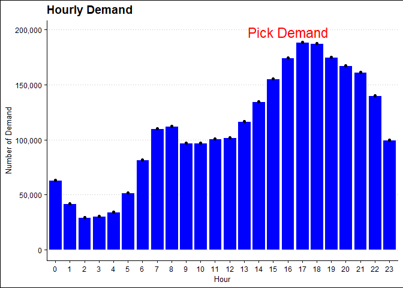

```r
# View(hour_data)


library(ggplot2)
library(ggthemes)
library(scales)
ggplot(hour_data, aes(x = Hour, y = Demand, group = 1)) +
  geom_bar(stat = 'identity', fill = 'blue',col = 'white') +
  geom_point() +
  scale_y_continuous(labels = comma) +
  annotate("text", label = "Pick Demand", x = 17, y = 198000, color = "red", size = 6) +
  ylab('Number of Demand') +
  theme_clean() +
  ggtitle('Hourly Demand')
```

```r
# It seems that about 17 and 18 we have pick demand.
```

```r
hour_month_demand = table(data$hour, data$month)
hour_month_demand
```

```
##
##        Jul   Aug   Sep
##   0  17953 21451 24133
##   1  11527 14471 16107
##   2   8562 10105 10702
##   3   9199 10376 10789
##   4  10040 11774 12675
##   5  14932 16525 20262
##   6  23456 24907 33307
##   7  32545 34064 43314
##   8  33387 34566 44477
##   9  28486 30195 38542
##   10 28558 30706 37634
##   11 30120 31778 38821
##   12 30900 32106 39193
##   13 35832 35764 45042
##   14 41357 40644 52643
##   15 46053 48197 61219
##   16 52403 53481 68224
##   17 58260 57122 73373
##   18 57268 55390 75040
##   19 52332 53008 69660
##   20 51859 51674 63988
##   21 49528 51354 60606
##   22 42218 46008 51817
##   23 29346 33609 36568
```

```r
class(hour_month_demand)
```

```
## [1] "table"
```

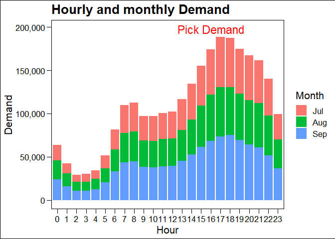

```r
hour_month_demand = as.data.frame(hour_month_demand)
# View(hour_month_demand)
names(hour_month_demand) = c('Hour','Month','Demand')

ggplot(hour_month_demand, aes(x = Hour, y = Demand, fill = Month)) +
  geom_bar(stat = 'identity') +
  scale_y_continuous(labels = comma) +
  annotate("text", label = "Pick Demand", x = 17, y = 198000, color = "red", size = 6) +
  theme_base() +
  ggtitle('Hourly and monthly Demand')
```

```r
library(dplyr)
July = data %>%
  filter(month == 'Jul')

Augest = data %>%
  filter(month == 'Aug')

September = data %>%
  filter(month == 'Sep')

hourly_demand_July = as.data.frame(table(July$hour))
names(hourly_demand_July) = c('Hour','Demand')
head(hourly_demand_July)
```

```
##   Hour Demand
## 1    0  17953
## 2    1  11527
## 3    2   8562
## 4    3   9199
## 5    4  10040
## 6    5  14932
```

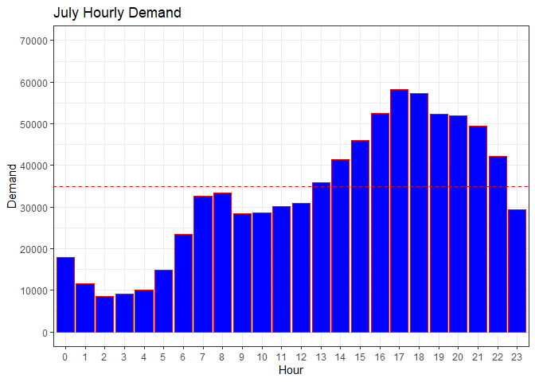

```r
p1 = ggplot(data = hourly_demand_July, aes(x = Hour, y = Demand)) +
  geom_bar(stat = 'identity', fill = 'blue', col = 'red') +
  ggtitle('July Hourly Demand') +
  theme_bw() +
  scale_y_continuous(breaks = seq(0,70000,by = 10000)) +
  expand_limits(y = c(0, 70000)) +
  geom_hline(yintercept=35000, linetype="dashed", color = "red")

p1
```

```r
hourly_demand_Augest = as.data.frame(table(Augest$hour))
names(hourly_demand_Augest) = c('Hour','Demand')
head(hourly_demand_Augest)
```

```
##   Hour Demand
## 1    0  21451
## 2    1  14471
## 3    2  10105
## 4    3  10376
## 5    4  11774
## 6    5  16525
```

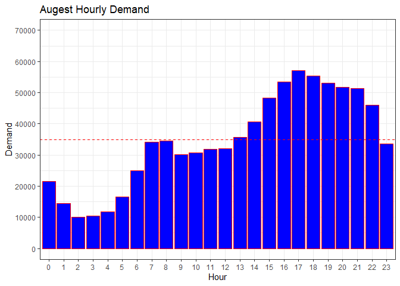

```r
p2 = ggplot(data = hourly_demand_Augest, aes(x = Hour, y = Demand)) +
  geom_bar(stat = 'identity', fill = 'blue', col = 'red') +
  ggtitle('Augest Hourly Demand') +
  theme_bw() +
  scale_y_continuous(breaks = seq(0,70000,by = 10000)) +
  expand_limits(y = c(0, 70000)) +
  geom_hline(yintercept=35000, linetype="dashed", color = "red")

p2
```

```r
hourly_demand_September = as.data.frame(table(September$hour))
names(hourly_demand_September) = c('Hour','Demand')
head(hourly_demand_September)
```

```
##   Hour Demand
## 1    0  24133
## 2    1  16107
## 3    2  10702
## 4    3  10789
## 5    4  12675
## 6    5  20262
```

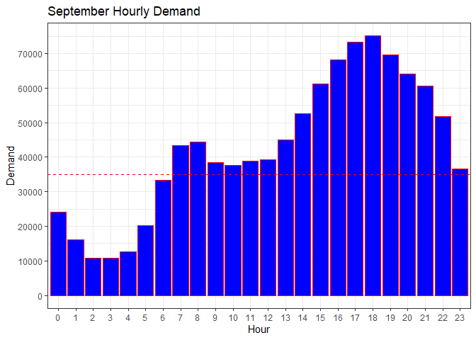

```r
p3 = ggplot(data = hourly_demand_September, aes(x = Hour, y = Demand)) +
  geom_bar(stat = 'identity', fill = 'blue', col = 'red') +
  ggtitle('September Hourly Demand') +
  theme_bw() +
  scale_y_continuous(breaks = seq(0,70000,by = 10000)) +
  expand_limits(y = c(0, 70000)) +
  geom_hline(yintercept=35000, linetype="dashed", color = "red")

p3
```

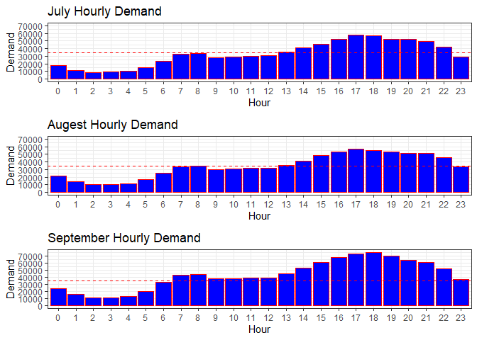

```r
plot1 = gridExtra::grid.arrange(p1, p2,p3, nrow = 3)
```

```r
# By seeing The graphs, we can answer question one:
# As for the solution, I think It seems that the peak demand every three months occurs about 17 and 18.
```

```r
# weekly demand

Weekly_demand = as.data.frame(table(data$dayofweek))
head(Weekly_demand)
```

```
##        Var1   Freq
## 1    Sunday 303105
## 2    Monday 322110
## 3   Tuesday 407808
## 4 Wednesday 398346
## 5  Thursday 425832
## 6    Friday 411789
```

```r
names(Weekly_demand) = c('Day','Demand')
Weekly_demand
```

```
##         Day Demand
## 1    Sunday 303105
## 2    Monday 322110
## 3   Tuesday 407808
## 4 Wednesday 398346
## 5  Thursday 425832
## 6    Friday 411789
## 7  Saturday 384542
```

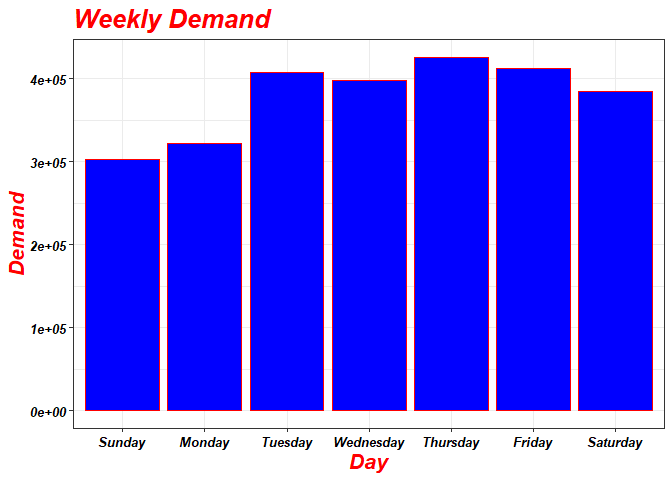

```r
red.bold.italic.text <- element_text(face = "bold.italic", color = "red", size = 16)
black.bold.italic.16.text <- element_text(face = "bold.italic", color = "black", size = 10)
ggplot(data = Weekly_demand, aes(x = Day, y = Demand)) +
  geom_bar(stat = 'identity', fill = 'blue', col = 'red') +
  ggtitle('Weekly Demand') +
  theme_bw() +
  theme(title = red.bold.italic.text, axis.title = red.bold.italic.text) +
  theme(axis.text = black.bold.italic.16.text)
```

```r
Week_Month_Demand = as.data.frame(table(data$dayofweek, data$month))
head(Week_Month_Demand)
```

```
##        Var1 Var2   Freq
## 1    Sunday  Jul  76327
## 2    Monday  Jul  93189
## 3   Tuesday  Jul 137454
## 4 Wednesday  Jul 147717
## 5  Thursday  Jul 148439
## 6    Friday  Jul 102735
```

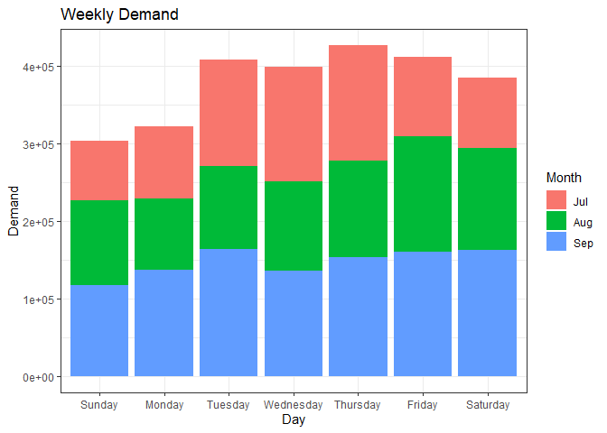

```r
names(Week_Month_Demand) = c('Day','Month','Demand')

ggplot(data = Week_Month_Demand, aes(x = Day, y = Demand, fill = Month)) +
  geom_bar(stat = 'identity') +
  ggtitle('Weekly Demand') +
  theme_bw()
```

```r
Week_Demand_Augest = as.data.frame(table(Augest$dayofweek))
head(Week_Demand_Augest)
```

```
##        Var1   Freq
## 1    Sunday 110246
## 2    Monday  91633
## 3   Tuesday 107124
## 4 Wednesday 115256
## 5  Thursday 124117
## 6    Friday 148674
```

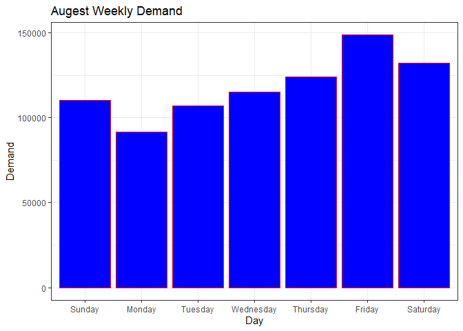

```r
names(Week_Demand_Augest) = c('Day','Demand')

p1 = ggplot(data = Week_Demand_Augest, aes(x = Day, y = Demand)) +
  geom_bar(stat = 'identity', fill = 'blue', col = 'red') +
  ggtitle('Augest Weekly Demand') +
  theme_bw()

p1
```

```r
Week_Demand_July = as.data.frame(table(July$dayofweek))
head(Week_Demand_July)
```

```
##        Var1   Freq
## 1    Sunday  76327
## 2    Monday  93189
## 3   Tuesday 137454
## 4 Wednesday 147717
## 5  Thursday 148439
## 6    Friday 102735
```

```r
names(Week_Demand_July) = c('Day','Demand')

p1 = ggplot(data = Week_Demand_July, aes(x = Day, y = Demand)) +
  geom_bar(stat = 'identity', fill = 'blue', col = 'red') +
  ggtitle('July Weekly Demand') +
  theme_bw()


Week_Demand_Augest = as.data.frame(table(Augest$dayofweek))
head(Week_Demand_Augest)
```

```
##        Var1   Freq
## 1    Sunday 110246
## 2    Monday  91633
## 3   Tuesday 107124
## 4 Wednesday 115256
## 5  Thursday 124117
## 6    Friday 148674
```

```r
names(Week_Demand_Augest) = c('Day','Demand')

p2 = ggplot(data = Week_Demand_Augest, aes(x = Day, y = Demand)) +
  geom_bar(stat = 'identity', fill = 'blue', col = 'red') +
  ggtitle('Augest Weekly Demand') +
  theme_bw()



Week_Demand_september = as.data.frame(table(September$dayofweek))
head(Week_Demand_september)
```

```
##        Var1   Freq
## 1    Sunday 116532
## 2    Monday 137288
## 3   Tuesday 163230
## 4 Wednesday 135373
## 5  Thursday 153276
## 6    Friday 160380
```

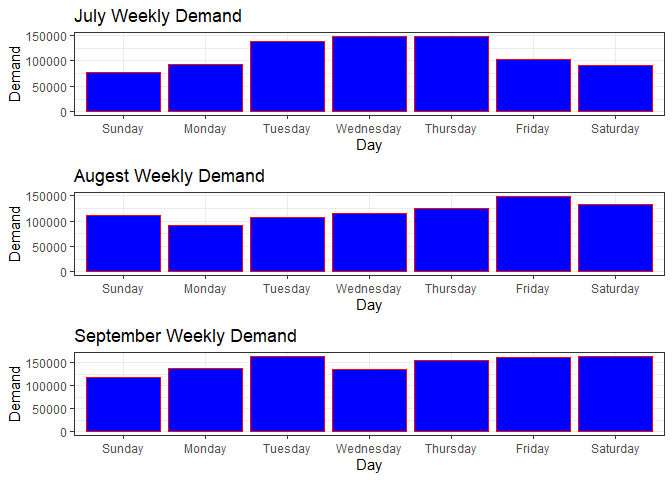

```r
names(Week_Demand_september) = c('Day','Demand')

p3 = ggplot(data = Week_Demand_september, aes(x = Day, y = Demand)) +
  geom_bar(stat = 'identity', fill = 'blue', col = 'red') +
  ggtitle('September Weekly Demand') +
  theme_bw()


plot2 = gridExtra::grid.arrange(p1, p2,p3, nrow = 3)
```

```r
Montly_Demand = as.data.frame(table(data$month))
head(Montly_Demand)
```

```
##   Var1    Freq
## 1  Jul  796121
## 2  Aug  829275
## 3  Sep 1028136
```

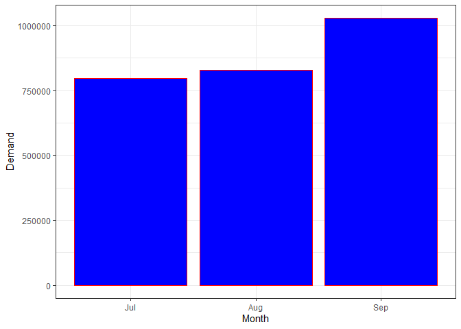

```r
names(Montly_Demand) = c('Month','Demand')

p = ggplot(data = Montly_Demand, aes(x = Month, y = Demand)) +
  geom_bar(stat = 'identity', col = 'red', fill = 'blue') +
  theme_bw()

p
```

```r
# It seems That in September The company has a big demand rather than the previous month.
```

As for The results:  
question one: Hourly demand on each day is about 17 & 18.  
question Two: This is not an obvious trend in each month.  
question one: on september, we have a higher demand rather than the other month.